# Clustering homework

```r
library(tidyverse)
library(janitor)
library(factoextra)
library(broom)
```

Task 1

Do some exploratory analysis on the data. Comment on findings.

```r
mall <- clean_names(read_csv("data/mall_customers.csv")) %>%
  select(-customer_id) %>%
  mutate(gender = ifelse(gender == "female", 1,2))
# just realized i only needed spending score and annual income for this





skimr::skim(mall)
```

Data summary

| Name | mall |
| --- | --- |
| Number of rows | 200 |
| Number of columns | 4 |
| _______________________ |  |
| Column type frequency: |  |
| numeric | 4 |
| ________________________ |  |
| Group variables | None |

**Variable type: numeric**

| skim_variable | n_missing | complete_rate | mean | sd | p0 | p25 | p50 | p75 | p100 | hist |
| --- | --- | --- | --- | --- | --- | --- | --- | --- | --- | --- |
| gender | 0 | 1 | 2.00 | 0.00 | 2 | 2.00 | 2.0 | 2 | 2 | ▁▁▇▁▁ |
| age | 0 | 1 | 38.85 | 13.97 | 18 | 28.75 | 36.0 | 49 | 70 | ▆▇▅▃▂ |
| annual_income_k | 0 | 1 | 60.56 | 26.26 | 15 | 41.50 | 61.5 | 78 | 137 | ▆▇▇▂▁ |
| spending_score_1_100 | 0 | 1 | 50.20 | 25.82 | 1 | 34.75 | 50.0 | 73 | 99 | ▃▃▇▃▃ |

Task 2

We are interested in creating a marketing campaign to target customers based on their spending score and annual income. Select an appropriate value for k and perform k-means clustering to find if there are meaningful clusters in the data to target the customers.

Elbow method maybe 3

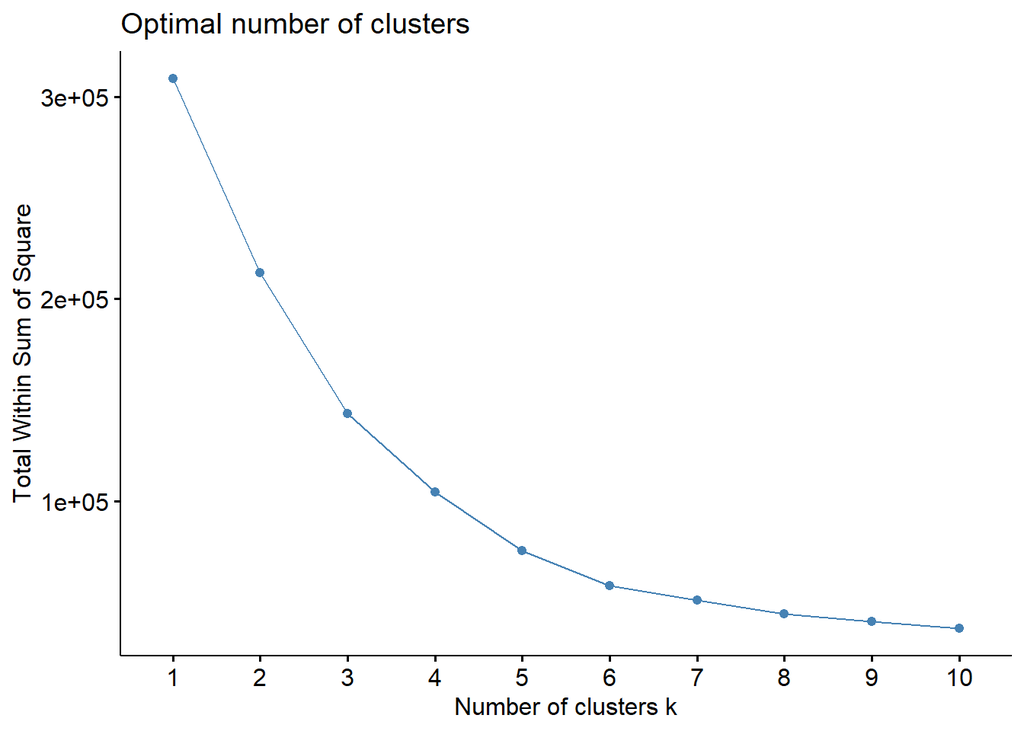

```r
fviz_nbclust(mall,
             kmeans,
             method = "wss",
             nstart = 25)
```

Silhouette 6 clusters

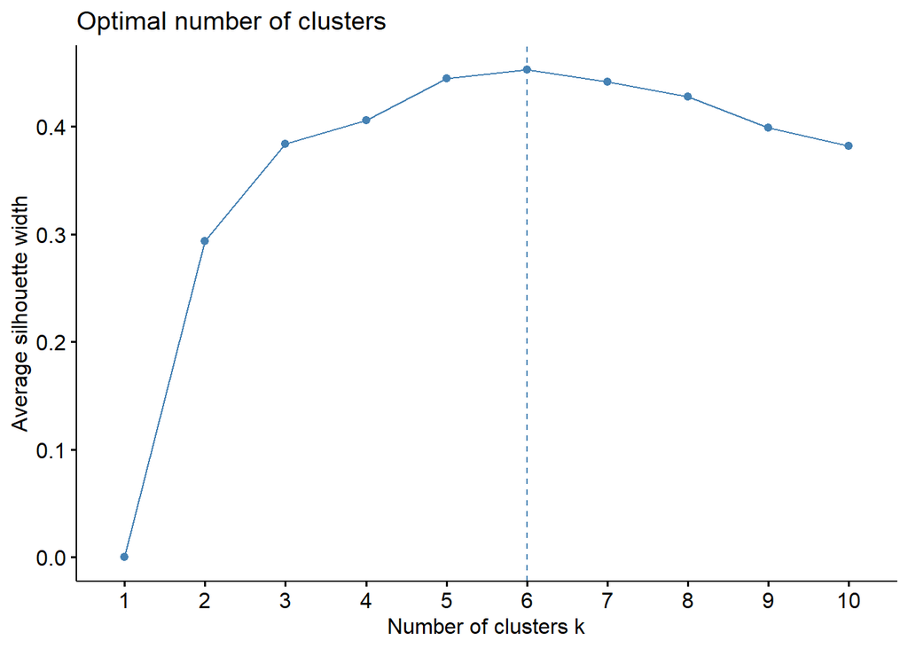

```r
fviz_nbclust(mall, kmeans, method = "silhouette", nstart = 25)
```

Gap 1

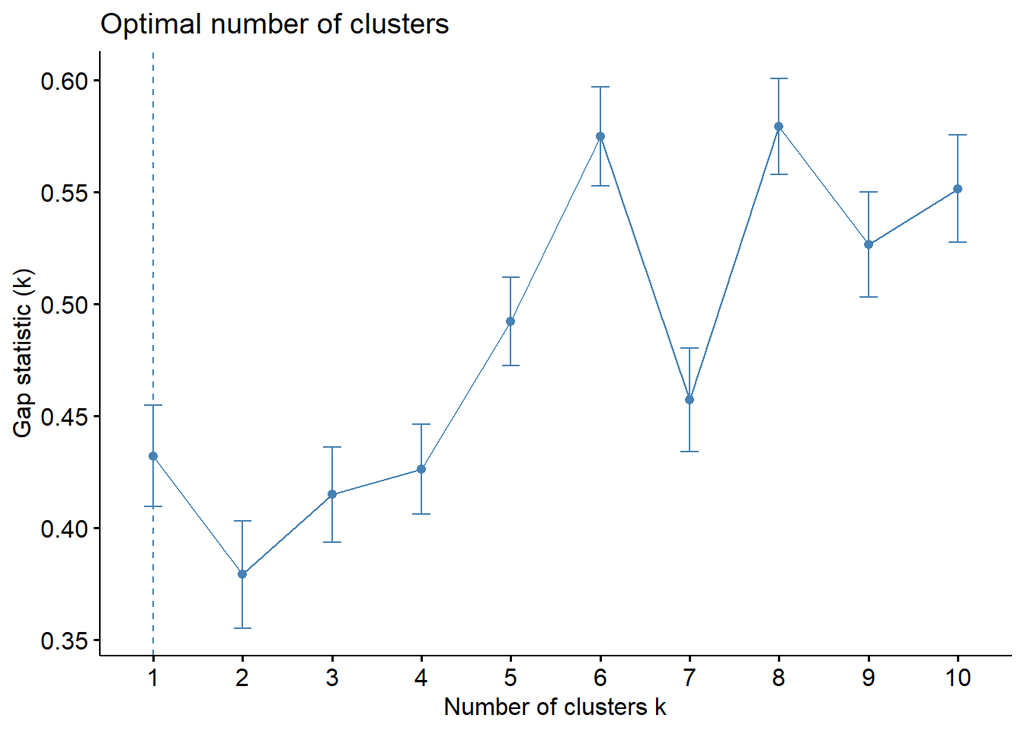

```r
fviz_nbclust(mall, kmeans, method = "gap_stat")
```

Choosing 3

```r
clustered_mall<- kmeans(mall, 3, nstart = 25)
```

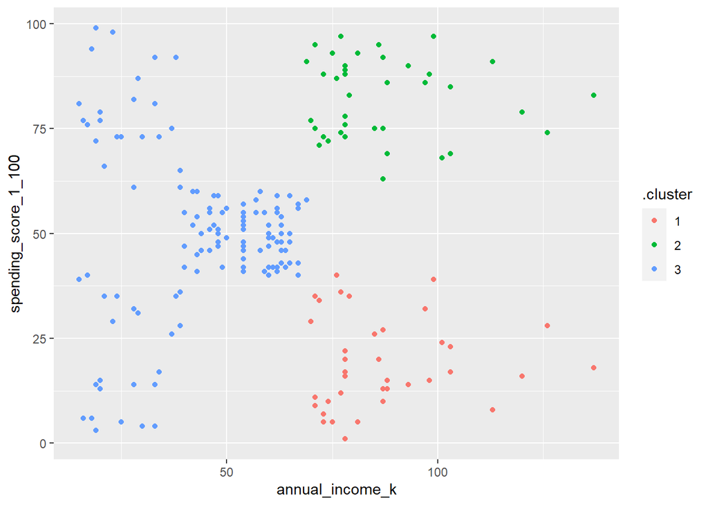

```r
clusters <- augment(clustered_mall, mall)

ggplot(clusters, aes(annual_income_k, spending_score_1_100, colour = .cluster)) +
  geom_point()
```

```r
clusters %>%
  group_by(.cluster) %>%
  summarise(mean(spending_score_1_100), mean(annual_income_k))
```

```
## # A tibble: 3 × 3
##   .cluster `mean(spending_score_1_100)` `mean(annual_income_k)`
##   <fct>                           <dbl>                   <dbl>
## 1 1                                18.6                    87
## 2 2                                82.1                    86.5
## 3 3                                49.8                    44.2
```

I think so but could be better, in the plot there is a clear group of 3 distinct clusters. 5 is better.

Cluster 1:

This group has high annual income 87k and low spending score 18.

Cluster 2:

This cluster has annual income of above aprox 86k but high spending score of 82 on avg.

Cluster 3:

This cluster has lower mean income of around 44k and a mean spending score of 49.

```r
clustered_mall2<- kmeans(mall, 5, nstart = 25)
```

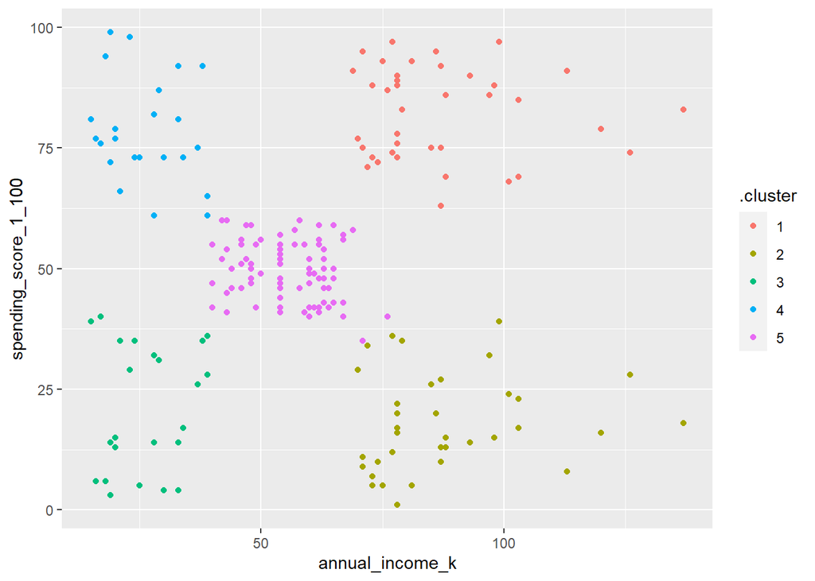

```r
clusters2 <- augment(clustered_mall2, mall)

ggplot(clusters2, aes(annual_income_k, spending_score_1_100, colour = .cluster)) +
  geom_point()
```

Yep 5 is much better !

```r
clusters2 %>%
  group_by(.cluster) %>%
  summarise(mean(spending_score_1_100), mean(annual_income_k))
```

```
## # A tibble: 5 × 3
##   .cluster `mean(spending_score_1_100)` `mean(annual_income_k)`
##   <fct>                           <dbl>                   <dbl>
## 1 1                                82.1                    86.5
## 2 2                                17.6                    87.8
## 3 3                                20.9                    26.3
## 4 4                                78.6                    26.3
## 5 5                                49.6                    55.3
```